# Multi-Fidelity GPR for Market Risk — Version 2

**Authors:** CHAQUIQ ELBADRE Youssef — NOUV Ratanakmuny

**Reference:** Lehdili, Oswald & Nguyen (2025), *Computation*, 13(6), 134.

## The reason choosing mGPR — The Cost Argument

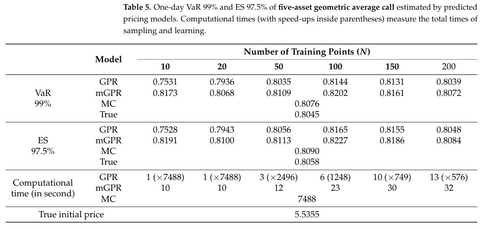

A common misreading of the paper is that mGPR should be *cheaper to train* than standard GPR. It is not, and the paper itself is explicit about this. **mGPR is cheaper in the dataset it requires, not in runtime.** In fact Table 5 of Lehdili, Oswald & Nguyen (2025) shows the opposite for training time — fitting the joint multi-fidelity model is slower than fitting a single HF-only GP because the joint covariance is larger and more hyperparameters have to be optimised (e.g. 10 s vs 1 s at $N = 10$).

The real cost in this problem is not the hyperparameter optimisation: it is the **number of calls to the expensive high-fidelity pricing engine**. Every HF evaluation costs 100 000 Monte Carlo paths, while an LF evaluation costs only 100 paths. The whole point of mGPR is therefore:

> *At the same budget of expensive HF evaluations, can we get better accuracy by adding cheap LF data?*

This is the sense in which mGPR is "cheaper": for a target accuracy it needs **fewer HF points** than a pure GPR, because the correlated LF data carries most of the shape information. Training time is a secondary cost that we pay once; HF data is the bottleneck that scales with the experiment.

The bottleneck is the **HF sampling cost**. Each HF evaluation costs 100 000 MC paths; the 200 LF evaluations (100 paths each) together cost the equivalent of **0.2 of one HF evaluation** — essentially free. So the fair comparison is at equal HF budget, and that is exactly what Section 3 does.

```python
import numpy as np
import matplotlib.pyplot as plt
import time, warnings
warnings.filterwarnings("ignore")

from scipy.stats import norm
from sklearn.gaussian_process import GaussianProcessRegressor
from sklearn.gaussian_process.kernels import Matern, ConstantKernel as C, WhiteKernel
from sklearn.preprocessing import StandardScaler

SEED = 42
np.random.seed(SEED)
print(f"Seed: {SEED}")
```

```
Seed: 42
```

## 1. Setup

Same market parameters and pricing engines as V1 and V2. We use the 5-asset geometric average call with MC_LF = 100 and MC_HF = 100,000.

```python
# === Market parameters ===
d = 5
S0    = np.array([90.0, 95.0, 99.0, 100.0, 97.0])
sigma = np.array([0.40, 0.20, 0.30, 0.15, 0.25])
r     = 0.01
T_mat = 2.0
K     = 100.0

corr_matrix = np.array([
    [1.0   , 0.0233, 0.1572, 0.1982, 0.1659],
    [0.0233, 1.0   , 0.3209, 0.3487, 0.1969],
    [0.1572, 0.3209, 1.0   , 0.0291, 0.3990],
    [0.1982, 0.3487, 0.0291, 1.0   , 0.1136],
    [0.1659, 0.1969, 0.3990, 0.1136, 1.0   ]
], dtype=float)

h = 1.0 / 252
M = 100_000
MC_HF = 100_000
MC_LF = 100

# === Pricing engines ===
def price_geom_call_bs(S, K, T, r, sigma, corr_matrix):
    """Closed-form BS price of geometric average call."""
    is_single = (S.ndim == 1)
    if is_single: S = S.reshape(1, -1)
    d_a = S.shape[1]
    sg2 = np.einsum('i,j,ij->', sigma, sigma, corr_matrix) / d_a**2
    sg = np.sqrt(sg2)
    logF = np.sum(np.log(S) + (r - 0.5*sigma**2)*T, axis=1)/d_a + 0.5*sg2*T
    F = np.exp(logF)
    d1 = (np.log(F/K) + 0.5*sg2*T) / (sg*np.sqrt(T))
    d2 = d1 - sg*np.sqrt(T)
    p = np.exp(-r*T) * (F*norm.cdf(d1) - K*norm.cdf(d2))
    return float(p[0]) if is_single else p

def price_geom_call_mc(S_batch, K, T, r, sigma, corr_matrix, n_paths, seed=0):
    """MC price of geometric call."""
    rng = np.random.default_rng(seed)
    n_sc, d_a = S_batch.shape
    L = np.linalg.cholesky(corr_matrix)
    prices = np.empty(n_sc)
    for i in range(n_sc):
        Z = rng.standard_normal((n_paths, d_a)) @ L.T
        S_T = S_batch[i]*np.exp((r-0.5*sigma**2)*T + sigma*np.sqrt(T)*Z)
        G_T = np.prod(S_T, axis=1)**(1.0/d_a)
        prices[i] = np.exp(-r*T)*np.mean(np.maximum(G_T-K, 0.0))
    return prices

def price_geom_call_mc_from_Z(S_batch, K, T, r, sigma, corr_matrix, Z):
    """MC price using pre-generated Z."""
    S_batch, Z = np.asarray(S_batch, np.float64), np.asarray(Z, np.float64)
    n_sc, d_a = S_batch.shape
    prices = np.empty(n_sc, np.float64)
    drift, vol = (r-0.5*sigma**2)*T, sigma*np.sqrt(T)
    for i in range(n_sc):
        S_T = S_batch[i]*np.exp(drift + vol*Z)
        G_T = np.prod(S_T, axis=1)**(1.0/d_a)
        prices[i] = np.exp(-r*T)*np.mean(np.maximum(G_T-K, 0.0))
    return prices

# Sanity check
p_bs = price_geom_call_bs(S0, K, T_mat, r, sigma, corr_matrix)
p_hf = price_geom_call_mc(S0.reshape(1,-1), K, T_mat, r, sigma, corr_matrix, MC_HF, seed=0)[0]
p_lf = price_geom_call_mc(S0.reshape(1,-1), K, T_mat, r, sigma, corr_matrix, MC_LF, seed=0)[0]
print(f"BS = {p_bs:.6f} | MC-HF = {p_hf:.6f} ({abs(p_hf-p_bs)/p_bs*100:.3f}%) | MC-LF = {p_lf:.6f} ({abs(p_lf-p_bs)/p_bs*100:.1f}%)")
```

```
BS = 5.535462 | MC-HF = 5.559617 (0.436%) | MC-LF = 4.388801 (20.7%)
```

```python
# === Scenarios + true prices ===
rng = np.random.default_rng(SEED)
L_chol = np.linalg.cholesky(corr_matrix)
Z_sc = rng.standard_normal((M, d)) @ L_chol.T
S_shocked = S0 * np.exp((r - 0.5*sigma**2)*h + sigma*np.sqrt(h)*Z_sc)

prices_true = price_geom_call_bs(S_shocked, K, T_mat, r, sigma, corr_matrix)
V0 = price_geom_call_bs(S0, K, T_mat, r, sigma, corr_matrix)
losses_true = V0 - prices_true
var_99_true = np.percentile(losses_true, 99)
es_975_true = losses_true[losses_true >= np.percentile(losses_true, 97.5)].mean()

print(f"V0 = {V0:.6f} | VaR 99% = {var_99_true:.6f} | ES 97.5% = {es_975_true:.6f}")
```

```
V0 = 5.535462 | VaR 99% = 0.850201 | ES 97.5% = 0.848325
```

```python
# === CRN data generation ===

def paired_mc_price_one_point(S, K, T, r, sigma, corr_matrix, mc_lf, mc_hf, seed):
    """LF + HF price for one point using common random numbers."""
    d_a = len(S)
    rng = np.random.default_rng(seed)
    L = np.linalg.cholesky(corr_matrix)
    Z = rng.standard_normal((mc_hf, d_a)) @ L.T
    y_lf = price_geom_call_mc_from_Z(S.reshape(1,-1), K, T, r, sigma, corr_matrix, Z[:mc_lf])[0]
    y_hf = price_geom_call_mc_from_Z(S.reshape(1,-1), K, T, r, sigma, corr_matrix, Z[:mc_hf])[0]
    return y_lf, y_hf

def generate_training_data(S_pool, N_hf, N_lf, K, T, r, sigma, corr_matrix,
                           mc_hf=100_000, mc_lf=100, seed=42, verbose=True):
    """Generate multi-fidelity training data with CRN."""
    assert N_hf <= N_lf
    rng = np.random.default_rng(seed)
    idx = rng.choice(S_pool.shape[0], size=N_lf, replace=False)
    X_lf = S_pool[idx].copy()
    X_hf = X_lf[:N_hf].copy()
    y_lf, y_hf = np.empty(N_lf, np.float64), np.empty(N_hf, np.float64)
    L = np.linalg.cholesky(corr_matrix)
    if verbose: print(f"Generating: N_hf={N_hf}, N_lf={N_lf}, mc_lf={mc_lf}")
    t0 = time.time()
    for j in range(N_hf):
        y_lf[j], y_hf[j] = paired_mc_price_one_point(X_hf[j], K, T, r, sigma, corr_matrix, mc_lf, mc_hf, seed+j)
    for j in range(N_hf, N_lf):
        Z = np.random.default_rng(seed+j).standard_normal((mc_lf, X_lf.shape[1])) @ L.T
        y_lf[j] = price_geom_call_mc_from_Z(X_lf[j].reshape(1,-1), K, T, r, sigma, corr_matrix, Z)[0]
    if verbose: print(f"Done in {time.time()-t0:.1f}s | corr = {np.corrcoef(y_lf[:N_hf], y_hf)[0,1]:.4f}")
    return X_hf, y_hf, X_lf, y_lf
```

```python
# === Standard GPR (sklearn) ===

def fit_gpr_sklearn(X_train, y_train, n_restarts=5):
    """Fit GPR with Matérn 5/2 kernel."""
    scaler = StandardScaler().fit(X_train)
    kernel = (C(1.0, (1e-3, 1e3)) * Matern(length_scale=1.0, length_scale_bounds=(1e-2, 1e2), nu=2.5)
              + WhiteKernel(noise_level=1e-6, noise_level_bounds=(1e-10, 1e-1)))
    gp = GaussianProcessRegressor(kernel=kernel, n_restarts_optimizer=n_restarts,
                                   normalize_y=True, random_state=SEED)
    gp.fit(scaler.transform(X_train), y_train)
    return gp, scaler

def predict_gpr_sklearn(gp, scaler, X_new):
    return gp.predict(scaler.transform(X_new))

def evaluate_surrogate(preds, prices_true, V0):
    """Compute MAPE, VaR 99%, ES 97.5%."""
    mape = np.mean(np.abs(preds - prices_true) / V0)
    losses = V0 - preds
    var_99 = np.percentile(losses, 99)
    es_975 = losses[losses >= np.percentile(losses, 97.5)].mean()
    return mape, var_99, es_975
```

## 2. Multi-Fidelity GPR — Methodology (V2)

### 2.1 Model

We use the AR(1) auto-regressive multi-fidelity model of Kennedy & O'Hagan (2000), which is also the model used in the reference paper:

$$ f_h(x) \;=\; \rho \, f_l(x) \;+\; \delta(x), $$

where $f_l \sim \mathcal{GP}(0, k_l)$ is the low-fidelity process, $\delta \sim \mathcal{GP}(0, k_\delta)$ is an independent HF discrepancy, and $\rho \in \mathbb{R}$ is the scalar coupling between the two fidelities. Both $k_l$ and $k_\delta$ are Matérn 5/2 kernels, each with its own signal variance and length-scale. A small white-noise term is added on the LF block to absorb the MC noise of the 100-path estimator.

Stacking $\mathbf{y} = [\mathbf{y}_l;\ \mathbf{y}_h]$, the joint covariance is

$$ K(\theta) \;=\; \begin{pmatrix} K_l(X_l,X_l) + \sigma_n^2 I & \rho\, K_l(X_l,X_h) \\[2pt] \rho\, K_l(X_h,X_l) & \rho^2\, K_l(X_h,X_h) + K_\delta(X_h,X_h) \end{pmatrix}, $$

with $\theta = (\sigma_l, \ell_l, \sigma_\delta, \ell_\delta, \rho, \sigma_n)$.

### 2.2 What changed from V1

**V1 (previous version) — two-step / profile approach.** V1 fitted the LF GP first, then froze its hyperparameters and searched for $\rho$ and the HF discrepancy kernel in a second stage (grid search followed by a profile negative log-likelihood). This decomposition is convenient but has two drawbacks:

1. the LF hyperparameters are estimated without knowing how they will be used by the HF level, so they can fit LF noise that the HF layer would otherwise down-weight
2. the coupling $\rho$ ends up unidentifiable when the LF data are noisy — we observed $\rho \to 0$ on the raw LF dataset in V1, and had to pre-smooth (de-noise) the LF observations to recover a sensible value.

$$ \theta^\star \;=\; \arg\min_{\theta}\; \tfrac{1}{2}\, \mathbf{y}^\top K(\theta)^{-1} \mathbf{y} \;+\; \tfrac{1}{2}\log\lvert K(\theta)\rvert \;+\; \text{const.} $$

We implement this as the `JointMFGPR` class below. A few practical points:

### 2.3 How to use it

```
# 1. Fit V2 mGPR jointly — one call, no de-noising
mgpr = fit_mgpr_ar1(X_hf, y_hf, X_lf, y_lf, verbose=True)

# 2. Predict HF prices at the M = 100,000 risk scenarios
preds = predict_mgpr(mgpr, S_shocked)

# 3. Risk metrics
losses = V0 - preds
VaR_99 = np.percentile(losses, 99)
ES_975 = losses[losses >= np.percentile(losses, 97.5)].mean()
```